# 70397 - Analyze capture-mark-recapture data using *mrmr*

## Fit model

- Code assumes that there are 8 physical cores available. Update parallel_chains and threads_per_chain as necessary based on actual number of cores.
- Add “adapt_delta = 0.99” or similar (after “treats_per_chain”) if divergent transitions occur.

```r
model_70397 <- fit_model(
                    data = data_70397,
                    chains = 4,
                    parallel_chains = 4,
                    cpp_options = list(stan_threads = TRUE),
                    threads_per_chain = 2,
                    adapt_delta = 0.8)
```

[output not shown]

[output cut: 43 more lines]

```
Chain 3 Iteration: 1900 / 2000 [ 95%]  (Sampling)
Chain 1 Iteration: 1900 / 2000 [ 95%]  (Sampling)
Chain 2 Iteration: 2000 / 2000 [100%]  (Sampling)
Chain 4 Iteration: 1900 / 2000 [ 95%]  (Sampling)
Chain 2 finished in 19.3 seconds.
Chain 3 Iteration: 2000 / 2000 [100%]  (Sampling)
Chain 3 finished in 19.6 seconds.
Chain 1 Iteration: 2000 / 2000 [100%]  (Sampling)
Chain 1 finished in 19.7 seconds.
Chain 4 Iteration: 2000 / 2000 [100%]  (Sampling)
Chain 4 finished in 19.9 seconds.

All 4 chains finished successfully.
Mean chain execution time: 19.6 seconds.
Total execution time: 20.0 seconds.
```

- Running model with default adapt_delta (0.8) resulted in zero divergent transition (0/4000).

### Save model object

- This step prevents having to rerun the model in the event of a crash during model visualizations in subsequent code chunks.
- Model files can be large, so this saves the file in a compressed format.
- To read model file, use “model_70397 <- read_rds(here::here(”out”, “model”, “70397_model.rds”))”

### Diagnose potential non-convergence of the MCMC algorithm

- Inspect traceplots and parameter summary table. In table, are any R<sub>hat</sub> values $\ge 1.01$?

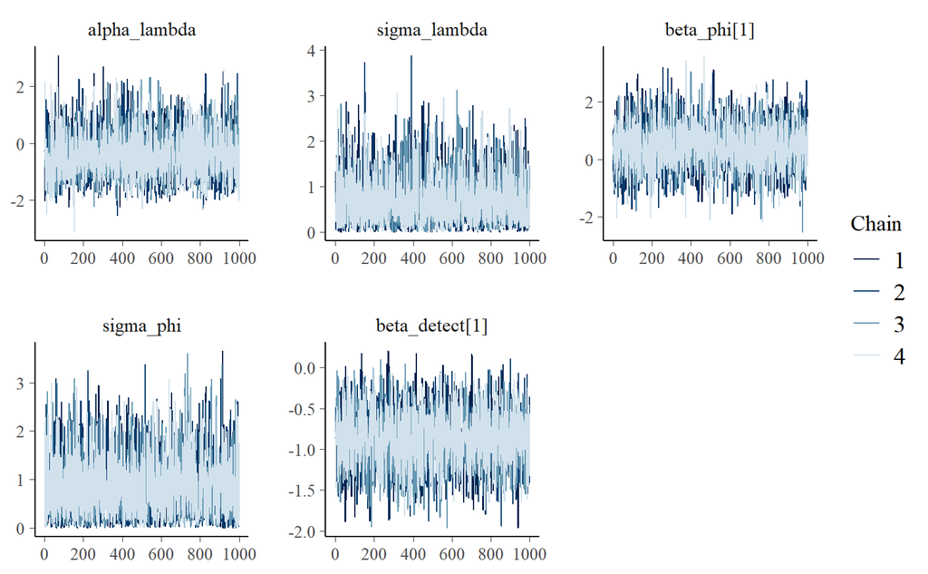

```r
pars_to_plot <- c('alpha_lambda',
                  'sigma_lambda',
                  'beta_phi',
                  'sigma_phi',
                  'beta_detect')
bayesplot::mcmc_trace(model_70397$m_fit$draws(pars_to_plot))
```

```r
model_70397$m_fit$summary(pars_to_plot)
```

| variable | mean | median | sd | mad | q5 | q95 | rhat | ess_bulk | ess_tail |
| --- | --- | --- | --- | --- | --- | --- | --- | --- | --- |
| alpha_lambda | -0.3794642 | -0.4722670 | 0.8091828 | 0.7984336 | -1.56089150 | 1.0757435 | 1.000673 | 3357.868 | 2744.211 |
| sigma_lambda | 0.6798865 | 0.5634690 | 0.5413314 | 0.5006992 | 0.05422170 | 1.7409855 | 1.000400 | 2601.217 | 1623.465 |
| beta_phi[1] | 0.4585303 | 0.4537140 | 0.7722273 | 0.7501823 | -0.80458860 | 1.7447985 | 1.001096 | 3677.068 | 2975.192 |
| sigma_phi | 0.8202200 | 0.7028990 | 0.6170701 | 0.6167082 | 0.06243963 | 2.0436690 | 1.000803 | 2472.932 | 1642.248 |
| beta_detect[1] | -0.8742410 | -0.8793865 | 0.3474248 | 0.3507854 | -1.44661300 | -0.2962821 | 1.000830 | 3430.333 | 2974.848 |

## Visualize model results

### Default plots

- Custom plots (produced in next code chunk: “plots_custom”) are often easier to interpret than the default plots produced by this code chunk.

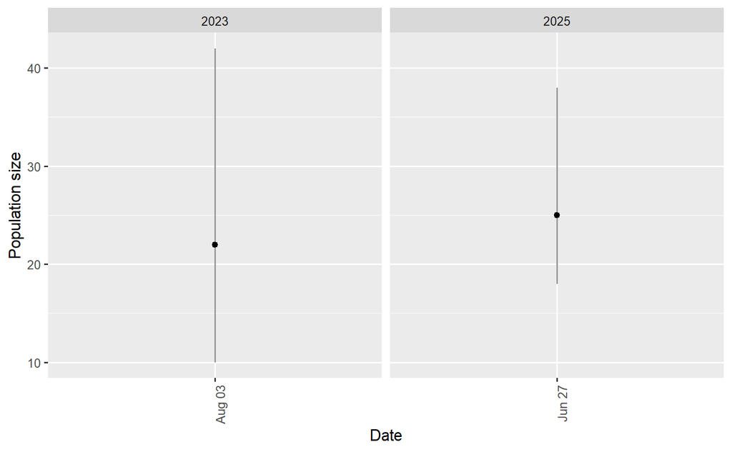

### Custom plots

- Remove p1 if translocations/reintroductions are not relevant.

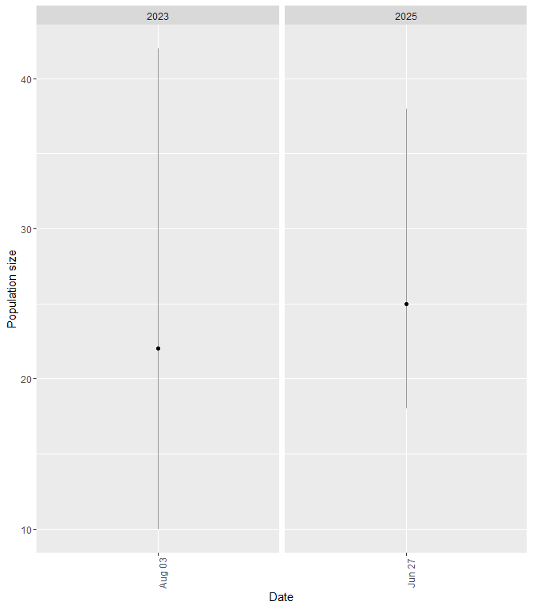

### Save custom plots

```r
ggsave(here::here("out", "plots", "70397_mrmr_plots.png"), width = 6.5, height = 7.2)
```

## Create survival tables

```r
survival_cohort <- survival_table(model_70397, by_cohort = TRUE)
survival_cohort

survival_ind <- survival_table(model_70397, by_individual = TRUE)
```

[output not shown]

### Save survival tables

```r
survival_cohort %>% write_csv(here::here("out", "tables", "70397_survival_cohort.csv"))
survival_ind %>% write_csv(here::here("out", "tables", "70397_survival_ind.csv"))
```